# wine_challenge_groupe20_short

### 1. Data preparation:

### 1.1 Data cleaning:

```python
dataset_r = pd.read_csv('winequality-red.csv', sep=';')
dataset_w = pd.read_csv('winequality-white.csv', sep=';')
print('Red wine data set: ', dataset_r.shape)
print('White wine data set: ', dataset_w.shape)
```

```
Red wine data set:  (1599, 12)
White wine data set:  (4898, 12)
```

The two dataset do not have the same number of samples. **The 'important' features are not necessary the same for white and red wine.**

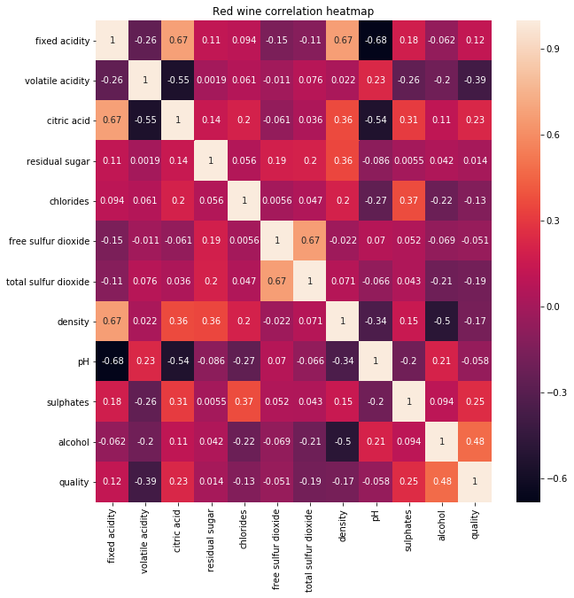

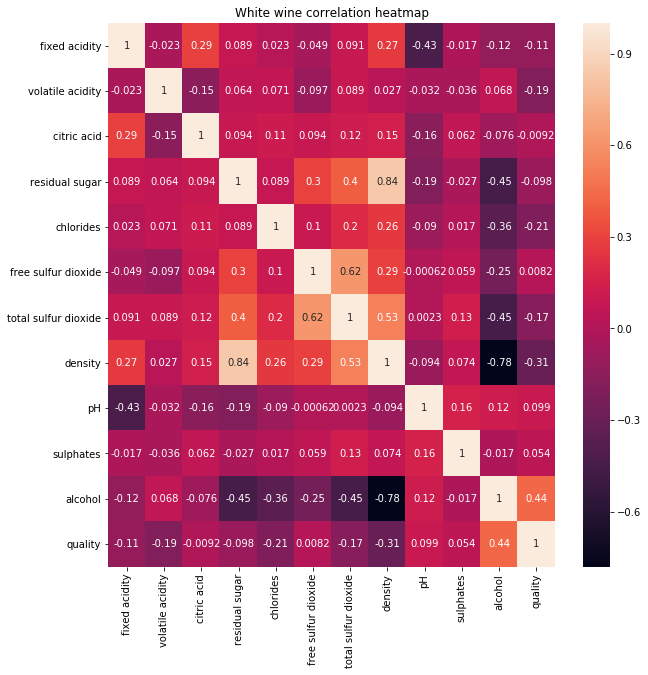

```python
fig, ax = plt.subplots(figsize=(10,10))
sn.heatmap(dataset_r.corr(), annot=True, ax=ax)
plt.title('Red wine correlation heatmap')
plt.show()

fig, ax = plt.subplots(figsize=(10,10))
sn.heatmap(dataset_w.corr(), annot=True, ax=ax)
plt.title('White wine correlation heatmap')
plt.show()
```

The correlation matrixes of the two datasets do not highlight the same feature importance between red and white wine.  
For red wine the important features that correlate with quality are:

- alcohol
- sulphates
- volatile acidity

For white wine the important features that correlate with quality are:

- alcohol
- density
- chloride

As they are not a lot of different features, it seems for us that there is no need to remove features that are highly correlated to prevent time-consuming computation.

### 1.2 Data Pre-processing

```python
# Binary classification problem
dataset_r.quality.loc[ (dataset_r.quality < 7)] = 0
dataset_w.quality.loc[ (dataset_w.quality < 7)] = 0

dataset_r.quality.loc[ (dataset_r.quality >= 7) ] = 1
dataset_w.quality.loc[ (dataset_w.quality >= 7) ] = 1
```

Now we create a new categorical feature type = 0(Red) or 1(White), then concat the datasets.

```python
# Create new feature for the type

dataset_r['type'] = 0
dataset_w['type'] = 1

# Concat
dataset = pd.concat([dataset_r, dataset_w], axis = 0)
```

We split our data into target and input for our algorithms

```python
y = dataset.quality.values
X = dataset.drop('quality', axis = 1).values
```

Standardisation the data in order to scale everything for our models.

```python
scale = StandardScaler().fit(X)

# transform the training data column
X_stand = scale.transform(X)
```

We split our data into training and testing dataset. We take 20% for the testing and 80% for the training.

```python
X_train, X_test, y_train, y_test = train_test_split(X_stand,y,test_size=0.2,random_state=SEED)
```

## 2. Model selection and performance

**Classes are unbalanced**. A Dummy classifier (always predicting class 0) would be our baseline with accuracy: **5220/6497 = 80%**

We will try to evaluate different models:

- Logistic regression
- SVC
- KNN
- Random forest

We will use cross validation to avoid overfitting We'll use either **log loss** and **accuracy** to evaluate our models.

### 2.1. Logistic regression

```python
log_clf = LogisticRegression(solver='lbfgs')
log_score = cross_validate(log_clf, X, y, scoring={'acc': accuracy_scorer, 'logloss': logloss_scorer}, cv=5)

print("Accuracy:", log_score['test_acc'].mean())
print("Log loss:  ", log_score['test_logloss'].mean())
```

```
Accuracy: 0.7975972049505536
Log loss:   6.9907810722723385
```

Accuracy is not better than baseline, a good log loss is close to 0. **This model is not better than dummy.**

### 2.2. SVM

```python
svm_clf = LinearSVC(tol=1e-6, max_iter=10000)
svm_score = cross_validate(svm_clf, X, y, scoring={'acc': accuracy_scorer, 'logloss': logloss_scorer}, cv=5)

print("Log loss: ", svm_score['test_acc'].mean())
print("Accuracy: ", svm_score['test_logloss'].mean())
```

```
Log loss:  0.6927668620832593
Accuracy:  10.611616415223294
```

Same problem : **This model is not better than dummy.** We can try to change the kernel, and tune the hyperparameters.

### 2.3. KNN

```python
knn_clf = KNeighborsClassifier(n_neighbors=50)
knn_score = cross_validate(knn_clf, X, y, scoring={'acc': accuracy_scorer, 'logloss': logloss_scorer}, cv=5)

print("Log loss: ", knn_score['test_acc'].mean())
print("Accuracy: ", knn_score['test_logloss'].mean())
```

```
Log loss:  0.8014462012198733
Accuracy:  6.857813383476963
```

The KNN model is slightly better than the baseline.

### 2.4. Random Forest

```python
rf_clf = RandomForestClassifier(n_estimators=150, max_depth=20)
rf_score = cross_validate(rf_clf, X, y, scoring={'acc': accuracy_scorer, 'logloss': logloss_scorer}, cv=5)

print("Log loss: ", rf_score['test_acc'].mean())
print("Accuracy: ", rf_score['test_logloss'].mean())
```

```
Log loss:  0.8165298750518151
Accuracy:  6.33686501209249
```

Our best model so far. This model deserves some **hyper parameters tunning** to take the most out of it.

### 3. Hyper parameters tunning

```python
rf_clf = RandomForestClassifier()

param = {
    'n_estimators': np.arange(100,500,50),
    'max_depth': [5, 10, 15, 20],
}

grid_rfc = GridSearchCV(rf_clf, param_grid=param, scoring=logloss_scorer, cv=5)
grid_rfc.fit(X, y)
```

```
GridSearchCV(cv=5, error_score='raise',
       estimator=RandomForestClassifier(bootstrap=True, class_weight=None, criterion='gini',
            max_depth=None, max_features='auto', max_leaf_nodes=None,
            min_impurity_decrease=0.0, min_impurity_split=None,
            min_samples_leaf=1, min_samples_split=2,
            min_weight_fraction_leaf=0.0, n_estimators=10, n_jobs=1,
            oob_score=False, random_state=None, verbose=0,
            warm_start=False),
       fit_params=None, iid=True, n_jobs=1,
       param_grid={'n_estimators': array([100, 150, 200, 250, 300, 350, 400, 450]), 'max_depth': [5, 10, 15, 20]},
       pre_dispatch='2*n_jobs', refit=True, return_train_score='warn',
       scoring=make_scorer(log_loss), verbose=0)
```

```python
grid_rfc.best_params_
```

```
{'max_depth': 5, 'n_estimators': 150}
```

```python
rf_clf = RandomForestClassifier(n_estimators=150, max_depth=5)
rf_score = cross_validate(rf_clf, X, y, scoring={'acc': accuracy_scorer, 'logloss': logloss_scorer}, cv=5)

print("Log loss: ", rf_score['test_acc'].mean())
print("Accuracy: ", rf_score['test_logloss'].mean())
```

```
Log loss:  0.8162246698643927
Accuracy:  6.347394731815474
```

### Some thoughts:

https://machinelearningmastery.com/cross-validation-for-imbalanced-classification/

Cross validation for unbalanced class problem is tricky and error prone because some fold can have few or no sample from some class leading to irrelevant score for the fold. We could have used a different method shown in the article above: **stratified KFold.**